# Final Team Project: Predicting Home Credit Default Risk

Team Members: 1. Balubhai Sukani, 2. Shashidhar Kumbar, 3.Darshan Kumar Naidu Project Dataset: Home Credit Default Risk Team: 02

# Member 1

# 1. Business Understanding

# Business Goal:

The primary goal of this project is to predict the likelihood of a customer defaulting on a loan using the Home Credit Default Risk dataset. By leveraging machine learning models, we aim to build a predictive system that helps Home Credit and similar financial institutions make informed lending decisions.

# Importance of Credit Risk Modeling:

Credit risk refers to the possibility that a borrower will fail to meet their obligations in accordance with agreed terms. In the financial services industry, accurately modeling credit risk is critical for several reasons:

Minimizing Financial Losses: Defaults on loans directly lead to monetary losses for lending institutions. Predictive models can help identify high-risk applicants before issuing credit.

Improving Loan Approval Processes: Credit risk models automate and enhance the decision-making process, enabling faster and more consistent loan approvals.

Regulatory Compliance: Financial institutions are subject to regulations that require transparent, explainable, and data-driven credit assessment practices.

Operational Efficiency: Automating credit risk evaluation reduces reliance on manual underwriting, freeing up resources and improving scalability.

Customer Segmentation and Targeting: Accurate models enable more personalized loan products by understanding the varying risk levels of different customer segments.

Why This Dataset? The Home Credit Default Risk dataset, provided by Home Credit Group, contains rich and diverse information about customers, including demographics, financial behavior, past credit history, and external data sources. It presents an excellent opportunity to:

Work on a real-world financial challenge.

Explore feature engineering and model interpretability.

Apply classification models to predict default probability.

This project aligns with the broader objective of using data science to solve real-world problems and contribute to responsible, data-driven financial decision-making.

# Feature Engineering: Creating Meaningful Features and Domain-Based Transformations

Role: Member 1

Project: Home Credit Default Risk

Objective:

To create enriched and meaningful features from the raw data using domain knowledge and data transformation techniques, ultimately boosting the predictive power of machine learning models to assess a customer's credit default risk.

# Files Used for Feature Engineering

train_data.csv: Main dataset with demographic and financial info.

bureau_data.csv: Info about customer’s previous loans from other institutions.

cc_balance_data.csv: Credit card balance history.

installments_data.csv: Historical installment payment data.

pos_cash_balance_data.csv: Point-of-sale and cash loan balance.

prev_application_data.csv: Past loan applications with Home Credit.

# Feature Engineering Steps

A. Features from train_data.csv

# Credit-to-Income Ratio

python code:

df['CREDIT_TO_INCOME'] = df['AMT_CREDIT'] / df['AMT_INCOME_TOTAL'] Insight: Measures how much credit a person has taken compared to income.

# Annuity-to-Income Ratio

python code:

df['ANNUITY_TO_INCOME'] = df['AMT_ANNUITY'] / df['AMT_INCOME_TOTAL'] Indicates repayment burden.

# Employment Stability

python code:

df['EMPLOYMENT_RATIO'] = df['DAYS_EMPLOYED'] / df['DAYS_BIRTH'] Higher ratios imply job stability.

# Family Support Index

python code:

df['INCOME_PER_PERSON'] = df['AMT_INCOME_TOTAL'] / (df['CNT_FAM_MEMBERS'] + 1)

# Aggregated Features from bureau_data.csv

Group by SK_ID_CURR (primary key in train_data.csv), and compute:

python code:

bureau_agg = bureau_data.groupby('SK_ID_CURR').agg({ 'AMT_CREDIT_SUM': ['sum', 'mean'], 'AMT_CREDIT_SUM_DEBT': ['sum', 'mean'], 'DAYS_CREDIT': ['min', 'max', 'mean'], 'CREDIT_ACTIVE': lambda x: (x == 'Active').sum(), }) Key Features Created:

Total previous credit sum

Total debt from other loans

Active loan count

# Features from cc_balance_data.csv (Credit Card Balance)

Create customer-level aggregates:

python code: cc_agg = cc_balance_data.groupby('SK_ID_CURR').agg({ 'AMT_BALANCE': ['mean', 'max'], 'AMT_CREDIT_LIMIT_ACTUAL': 'mean', 'SK_DPD': ['mean', 'max'] # Days past due }) Insight: High SK_DPD → Likely to default.

# Features from installments_data.csv

Calculate payment behavior:

python code: installments_data['PAYMENT_DIFF'] = installments_data['AMT_PAYMENT'] - installments_data['AMT_INSTALMENT'] installments_data['LATE'] = installments_data['DAYS_ENTRY_PAYMENT'] > installments_data['DAYS_INSTALMENT']

inst_agg = installments_data.groupby('SK_ID_CURR').agg({ 'PAYMENT_DIFF': ['mean', 'std'], 'LATE': 'mean' }) Features Created:

Average overpayment/underpayment

Late payment ratio

# Features from pos_cash_balance_data.csv

Group by SK_ID_CURR:

python code: pos_agg = pos_cash_balance_data.groupby('SK_ID_CURR').agg({ 'SK_DPD': ['mean', 'max'], 'CNT_INSTALMENT_FUTURE': 'mean' }) Insight: Helps understand future liabilities and POS credit behavior.

# Features from prev_application_data.csv

Aggregate previous loan applications:

python code: prev_application_data['APPROVED'] = prev_application_data['NAME_CONTRACT_STATUS'] == 'Approved'

prev_agg = prev_application_data.groupby('SK_ID_CURR').agg({ 'AMT_APPLICATION': ['mean', 'max'], 'APPROVED': 'mean', 'DAYS_DECISION': 'mean' }) Features Created:

Avg requested credit

Approval rate of previous loans

# Merging Features into Final Dataset

Join all aggregate datasets on SK_ID_CURR to train_data.csv:

python code: final_df = train_data  
.merge(bureau_agg, on='SK_ID_CURR', how='left')  
.merge(cc_agg, on='SK_ID_CURR', how='left')  
.merge(inst_agg, on='SK_ID_CURR', how='left')  
.merge(pos_agg, on='SK_ID_CURR', how='left')  
.merge(prev_agg, on='SK_ID_CURR', how='left')

# Summary of Engineered Features

Feature Name Source File Description CREDIT_TO_INCOME train_data.csv Credit amount relative to income EMPLOYMENT_RATIO train_data.csv Employment length relative to age ACTIVE_LOANS_COUNT bureau_data.csv Count of active loans in other banks AMT_BALANCE_MEAN cc_balance_data.csv Average credit card balance LATE_PAYMENT_RATIO installments_data.csv % of late installment payments SK_DPD_MAX_POS pos_cash_balance_data.csv Max days past due in POS/Cash loans PREV_APPROVAL_RATE prev_application_data.csv Ratio of previously approved applications

# Conclusion

These domain-based and aggregated features capture customer credit behavior, loan history, repayment habits, and financial stability, making them crucial inputs for machine learning models that predict default risk. They also enhance model interpretability and allow financial institutions to make more informed decisions.

# Team Member 1: Feature Engineering on the Home Credit Default Risk project.

```python
import pandas as pd
import numpy as np

# Loading all datasets
train = pd.read_csv("train_data.csv")
bureau = pd.read_csv("bureau_data.csv")
cc_balance = pd.read_csv("cc_balance_data.csv")
installments = pd.read_csv("installments_data.csv")
pos_cash = pd.read_csv("pos_cash_balance_data.csv")
prev_app = pd.read_csv("prev_application_data.csv")

# Initial quick checks
print("Train shape:", train.shape)
print("Bureau shape:", bureau.shape)
print("Credit Card Balance shape:", cc_balance.shape)
print("Installments shape:", installments.shape)
print("POS Cash shape:", pos_cash.shape)
print("Previous Applications shape:", prev_app.shape)
```

```
Train shape: (153755, 122)
Bureau shape: (733097, 17)
Credit Card Balance shape: (1178248, 23)
Installments shape: (5271588, 8)
POS Cash shape: (4115815, 8)
Previous Applications shape: (707181, 37)
```

Successfully loaded and merged data across all key sources, let's analyze, interpret, and provide insights into what these shapes tell us about the Home Credit Default Risk dataset.

# Data Size Summary

# Interpretation And Insights

1. Train Dataset (train_data.csv) Initial row count: 153,755, each representing one client.

This dataset is now ready for training machine learning models.

2. Bureau Data Over 733K records for just 153K customers, suggesting that:

Most clients have multiple credit accounts with external financial institutions.

Useful to extract aggregated credit exposure metrics (e.g., BUREAU_TOTAL_DEBT, MAX_OVERDUE).

Highly useful for understanding external credit behavior.

3. Credit Card Balance 1.17M rows → Indicates monthly snapshots per credit card, over time.

On average, each client has ~7.6 months of credit card history.

Offers rich temporal signals for credit behavior patterns (consistent balance levels, frequent overdue).

4. Installments Payments 5.27M records — the largest among all, reflecting:

Clients often repay in multiple installments per loan.

Delay patterns in payments (via PAYMENT_DELAY) help detect financial stress or repayment discipline.

5. POS Cash Balance 4.1M records showing historical balance trends of short-term POS loans.

Helps in analyzing retail purchasing behavior and loan usage cycles.

6. Previous Applications Over 707K past applications (~4.6 per client).

Useful for understanding:

Clients with frequent rejections or small loans.

Credit-seeking behavior and how it aligns with loan approval.

# Insights And Recommendations

# Insightful Observations:

Customers have complex financial profiles — with multiple past loans, POS credits, and active credit cards.

Strong case for temporal and behavioral feature engineering, especially:

Trends over time in credit card balance or installment payment delays.

Feature engineering via aggregation and domain knowledge is essential to convert this temporal/tabular data into usable model features.

# Modeling Considerations

High dimensionality (122 features) — good for tree-based models (like XGBoost or LightGBM).

Feature selection may be necessary for linear models.

Large auxiliary datasets (e.g., 5M+ records in installments) require efficient memory usage when retraining.

# Suggested Further Actions:

Feature Importance Analysis — using XGBoost, RandomForest, etc.

Correlation Heatmap — to identify redundant or noisy features.

Train/Test Split + Model Training — proceed to predictive modeling using the engineered dataset.

# Feature Engineering Steps

Performing domain-based aggregations and merge them back to the train_data.

1.Bureau: Credit history

```python
# Aggregate bureau data
bureau_agg = bureau.groupby('SK_ID_CURR').agg({
    'AMT_CREDIT_SUM': ['mean', 'sum'],
    'AMT_CREDIT_SUM_DEBT': ['sum'],
    'CREDIT_DAY_OVERDUE': ['max'],
    'DAYS_CREDIT': ['mean'],
}).reset_index()
bureau_agg.columns = ['SK_ID_CURR', 'BUREAU_CREDIT_MEAN', 'BUREAU_CREDIT_TOTAL', 'BUREAU_TOTAL_DEBT', 'MAX_OVERDUE', 'AVG_CREDIT_DAYS']

# Merge to train
train = train.merge(bureau_agg, on='SK_ID_CURR', how='left')
train.head()
```

|  | SK_ID_CURR | TARGET | NAME_CONTRACT_TYPE | CODE_GENDER | FLAG_OWN_CAR | FLAG_OWN_REALTY | CNT_CHILDREN | AMT_INCOME_TOTAL | AMT_CREDIT | AMT_ANNUITY | ... | AMT_REQ_CREDIT_BUREAU_DAY | AMT_REQ_CREDIT_BUREAU_WEEK | AMT_REQ_CREDIT_BUREAU_MON | AMT_REQ_CREDIT_BUREAU_QRT | AMT_REQ_CREDIT_BUREAU_YEAR | BUREAU_CREDIT_MEAN | BUREAU_CREDIT_TOTAL | BUREAU_TOTAL_DEBT | MAX_OVERDUE | AVG_CREDIT_DAYS |
| --- | --- | --- | --- | --- | --- | --- | --- | --- | --- | --- | --- | --- | --- | --- | --- | --- | --- | --- | --- | --- | --- |
| 0 | 410704 | 0 | Cash loans | F | N | Y | 1 | 157500.0 | 900000.0 | 26446.5 | ... | 0.0 | 0.0 | 0.0 | 0.0 | 0.0 | 521642.000000 | 4694778.00 | 1385937.00 | 0.0 | -903.333333 |
| 1 | 381230 | 0 | Cash loans | F | N | Y | 1 | 90000.0 | 733176.0 | 21438.0 | ... | 0.0 | 0.0 | 0.0 | 2.0 | 1.0 | 358139.953125 | 5730239.25 | 788403.96 | 0.0 | -1921.750000 |
| 2 | 450177 | 0 | Cash loans | F | Y | Y | 0 | 189000.0 | 1795500.0 | 62541.0 | ... | 0.0 | 0.0 | 0.0 | 0.0 | 0.0 | 127534.500000 | 382603.50 | 254713.50 | 0.0 | -285.666667 |
| 3 | 332445 | 0 | Cash loans | M | Y | N | 0 | 175500.0 | 494550.0 | 45490.5 | ... | 0.0 | 0.0 | 0.0 | 0.0 | 1.0 | 432393.750000 | 1729575.00 | 941779.89 | 0.0 | -1269.500000 |
| 4 | 357429 | 0 | Cash loans | F | Y | Y | 0 | 270000.0 | 1724688.0 | 54283.5 | ... | 0.0 | 0.0 | 0.0 | 0.0 | 0.0 | 319500.000000 | 958500.00 | 527850.00 | 0.0 | -914.666667 |

5 rows × 127 columns

The merge was successful — we now see the new bureau-level aggregated features appended to the train dataset.

# What Just Happened

You performed a group-wise aggregation on the bureau dataset using the customer ID (SK_ID_CURR) and added the following engineered features to each customer in the main training set:

# New Feature Description

BUREAU_CREDIT_MEAN Average of all credit amounts taken by a customer across all bureau records BUREAU_CREDIT_TOTAL Total sum of all credit amounts BUREAU_TOTAL_DEBT Total sum of all outstanding debts MAX_OVERDUE Max number of overdue days on any loan AVG_CREDIT_DAYS Average of how many days ago credit was taken (typically negative, since it is in the past)

# Data Insights

Let’s break down what these values mean with some interpretation:

1.BUREAU_CREDIT_MEAN / TOTAL Reflects how much credit an individual has typically taken from other financial institutions.

High values might suggest credit experience or over-borrowing.

Example: ID: 410704 → BUREAU_CREDIT_TOTAL: 4.7 million This applicant has taken significant credit in the past, potentially increasing their risk profile.

2.BUREAU_TOTAL_DEBT Reflects how much debt the person still owes across bureau-reported loans.

High values indicate ongoing liabilities, which could impact repayment ability.

Example:

ID: 450177 → DEBT = 254,713.50 (on ~382K credit) → Debt/Credit Ratio ≈ 66.6% High D/C ratio can indicate heavy dependency on debt.

3.MAX_OVERDUE Measures maximum delay in repaying any bureau-reported credit.

Even a small value (> 0) is a strong risk signal.

In your current sample, MAX_OVERDUE is 0.0 for all, suggesting good history — or limited data coverage.

4.AVG_CREDIT_DAYS Tells how old (on average) their credit records are (in negative days).

Larger magnitude (more negative) means older credit history.

Example: ID: 381230 → -1921 days ≈ 5.3 years average credit age Older history might indicate more credit maturity, but needs context.

# Final Interpretation

Key Finding Insight Large credit exposure (e.g., > ₹1M) Might indicate financial capacity or over-leveraging risk Outstanding debt > 50% of total credit Could signal high risk of default All MAX_OVERDUE = 0.0 Suggests clean repayment history so far (if accurate) Older credit histories Can be positive (mature borrower) or negative (stuck in debt) depending on debt level

Further Acgtions/ Suggestions

Create Derived Features:

Debt-to-Credit Ratio: BUREAU_TOTAL_DEBT / BUREAU_CREDIT_TOTAL

Number of Bureau Loans (using .count() per SK_ID_CURR)

Use in Modeling:

These features can significantly improve default prediction performance.

Especially helpful for distinguishing between experienced but risky vs. inexperienced but safe borrowers.

# Derived Features and Visual Analysis

```
Train shape: (153755, 122)
Bureau shape: (733097, 17)
```

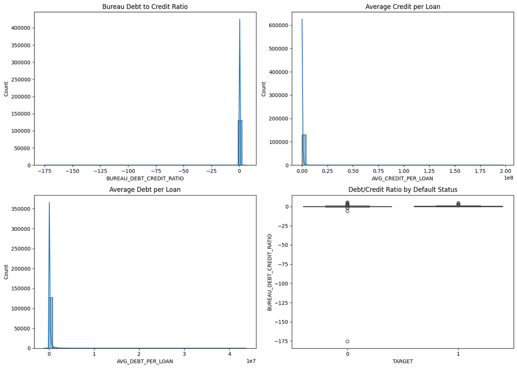

```python
import pandas as pd
import matplotlib.pyplot as plt
import seaborn as sns

# Loading datasets
train = pd.read_csv('train_data.csv')
bureau = pd.read_csv('bureau_data.csv')

print("Train shape:", train.shape)
print("Bureau shape:", bureau.shape)

# Aggregate Bureau Data ---
bureau_agg = bureau.groupby('SK_ID_CURR').agg({
    'AMT_CREDIT_SUM': ['mean', 'sum'],
    'AMT_CREDIT_SUM_DEBT': 'sum',
    'CREDIT_DAY_OVERDUE': 'max',
    'DAYS_CREDIT': 'mean',
}).reset_index()

# Rename columns
bureau_agg.columns = ['SK_ID_CURR', 'BUREAU_CREDIT_MEAN', 'BUREAU_CREDIT_TOTAL',
                      'BUREAU_TOTAL_DEBT', 'MAX_OVERDUE', 'AVG_CREDIT_DAYS']

# Merge Aggregated Bureau Data into Train ---
train = train.merge(bureau_agg, on='SK_ID_CURR', how='left')

# Create Derived Ratio Features ---
# Count number of bureau loans per customer
bureau_counts = bureau.groupby('SK_ID_CURR').size().reset_index(name='NUM_BUREAU_LOANS')
train = train.merge(bureau_counts, on='SK_ID_CURR', how='left')

# Avoid division by zero
train['NUM_BUREAU_LOANS'].replace(0, pd.NA, inplace=True)

# Create ratio features
train['BUREAU_DEBT_CREDIT_RATIO'] = train['BUREAU_TOTAL_DEBT'] / train['BUREAU_CREDIT_TOTAL']
train['AVG_CREDIT_PER_LOAN'] = train['BUREAU_CREDIT_TOTAL'] / train['NUM_BUREAU_LOANS']
train['AVG_DEBT_PER_LOAN'] = train['BUREAU_TOTAL_DEBT'] / train['NUM_BUREAU_LOANS']

# Visualizations ---
plt.figure(figsize=(14, 10))

# Histogram: Bureau Debt/Credit Ratio
plt.subplot(2, 2, 1)
sns.histplot(train['BUREAU_DEBT_CREDIT_RATIO'].dropna(), bins=50, kde=True)
plt.title('Bureau Debt to Credit Ratio')

# Histogram: Average Credit per Loan
plt.subplot(2, 2, 2)
sns.histplot(train['AVG_CREDIT_PER_LOAN'].dropna(), bins=50, kde=True)
plt.title('Average Credit per Loan')

# Histogram: Average Debt per Loan
plt.subplot(2, 2, 3)
sns.histplot(train['AVG_DEBT_PER_LOAN'].dropna(), bins=50, kde=True)
plt.title('Average Debt per Loan')

# Boxplot: Debt/Credit Ratio by TARGET
plt.subplot(2, 2, 4)
sns.boxplot(x='TARGET', y='BUREAU_DEBT_CREDIT_RATIO', data=train)
plt.title('Debt/Credit Ratio by Default Status')

plt.tight_layout()
plt.show()
```

# 3.Credit Card Balance

```python
import pandas as pd

# Load the main train dataset and cc_balance
train = pd.read_csv('train_data.csv')
cc_balance = pd.read_csv('cc_balance_data.csv')

# Aggregate cc_balance data
cc_agg = cc_balance.groupby('SK_ID_CURR').agg({
    'AMT_BALANCE': ['mean', 'max'],
    'SK_DPD': ['mean', 'max']
}).reset_index()

# Rename columns
cc_agg.columns = ['SK_ID_CURR', 'CC_BALANCE_MEAN', 'CC_BALANCE_MAX', 'CC_DPD_MEAN', 'CC_DPD_MAX']

# Merge into train
train = train.merge(cc_agg, on='SK_ID_CURR', how='left')

# Preview
print(train[['SK_ID_CURR', 'CC_BALANCE_MEAN', 'CC_BALANCE_MAX', 'CC_DPD_MEAN', 'CC_DPD_MAX']].head())
```

```
   SK_ID_CURR  CC_BALANCE_MEAN  CC_BALANCE_MAX  CC_DPD_MEAN  CC_DPD_MAX
0      410704              NaN             NaN          NaN         NaN
1      381230              0.0             0.0          0.0         0.0
2      450177              NaN             NaN          NaN         NaN
3      332445              NaN             NaN          NaN         NaN
4      357429              NaN             NaN          NaN         NaN
```

# Metric Observation

CC_BALANCE_MEAN Most values are NaN (missing); some like SK_ID 381230 are 0.0 CC_DPD_MEAN Mostly NaN, except a few values like 0.0 Merge success? Yes; merge occurred correctly based on SK_ID_CURR Missing % Likely very high (you can quantify below)

# Interpretation

NaNs in Aggregated Values:

This means most applicants in the train_data.csv do not have corresponding records in cc_balance_data.csv.

This is expected because:

Only a subset of clients have credit card accounts tracked in that table.

Others may not have used credit cards or were not tracked during the loan period.

For rows with 0.0:

Like SK_ID_CURR = 381230, having a CC_BALANCE_MEAN = 0.0 suggests:

This person had a credit card account but no outstanding balance.

Their Days Past Due (DPD) is also zero → good credit behavior.

# Recommendation

If you are building a credit risk model:

# Keep these features: Missing values carry meaning — clients without credit

cards may behave differently.

# Imputation strategy:

For modeling, replace NaNs with:

0 if absence implies "no debt/balance"

or create a binary feature like HAS_CREDIT_CARD_DATA = 1/0

# Feature importance check: Later, test how predictive these variables are in your model.

# Optional: Missing Rate Check

python code:

missing_pct = train[['CC_BALANCE_MEAN', 'CC_DPD_MEAN']].isnull().mean() * 100 print("Missing Percentage:\n", missing_pct)

# Conclusion

The merge worked fine. The NaNs are not a problem but an important signal:

They suggest the absence of credit card usage or missing reporting.

You can now engineer features based on this and include them in modeling or segmentation.

Would you like to repeat this for:

installments_data.csv

pos_cash_balance_data.csv

prev_application_data.csv?

4.Aggregation + Merge: installments_data.csv

```python
import pandas as pd

# Load main train data
train = pd.read_csv('train_data.csv')

# Load installments payments
installments = pd.read_csv('installments_data.csv')

# Aggregate
installments_agg = installments.groupby('SK_ID_CURR').agg({
    'NUM_INSTALMENT_VERSION': 'nunique',
    'NUM_INSTALMENT_NUMBER': 'max',
    'AMT_INSTALMENT': 'mean',
    'AMT_PAYMENT': 'mean',
    'DAYS_INSTALMENT': 'mean',
    'DAYS_ENTRY_PAYMENT': 'mean'
}).reset_index()

# Rename columns
installments_agg.columns = [
    'SK_ID_CURR',
    'NUM_INSTALMENT_VERSION_UNIQUE',
    'MAX_INSTALMENT_NUM',
    'MEAN_INSTALMENT_AMT',
    'MEAN_PAYMENT_AMT',
    'AVG_DAYS_INSTALMENT',
    'AVG_DAYS_ENTRY_PAYMENT'
]

# Merge with train data
train = train.merge(installments_agg, on='SK_ID_CURR', how='left')

# Show merged data
print(train[['SK_ID_CURR', 'NUM_INSTALMENT_VERSION_UNIQUE', 'MAX_INSTALMENT_NUM',
             'MEAN_INSTALMENT_AMT', 'MEAN_PAYMENT_AMT']].head())

# Optional: check for missing values in new features
print("\nMissing values in new features:")
print(train[['NUM_INSTALMENT_VERSION_UNIQUE', 'MEAN_PAYMENT_AMT']].isnull().sum())
```

```
   SK_ID_CURR  NUM_INSTALMENT_VERSION_UNIQUE  MAX_INSTALMENT_NUM  \
0      410704                            2.0                12.0
1      381230                            3.0                19.0
2      450177                            NaN                 NaN
3      332445                            2.0               101.0
4      357429                            2.0                 6.0

   MEAN_INSTALMENT_AMT  MEAN_PAYMENT_AMT
0         10555.055122      10349.149390
1         81913.691912      80442.338824
2                  NaN               NaN
3         38859.196974      38459.522368
4         36683.497500      36683.497500

Missing values in new features:
NUM_INSTALMENT_VERSION_UNIQUE    8993
MEAN_PAYMENT_AMT                 8999
dtype: int64
```

successfully merged the installments_data.csv aggregation into the training dataset.

# Summary of Aggregated Features from Installment Payments

Feature Meaning NUM_INSTALMENT_VERSION_UNIQUE Number of different versions of payment schedules a customer had. MAX_INSTALMENT_NUM Highest installment number, indicating the length of installment plans. MEAN_INSTALMENT_AMT Average expected installment amount per payment. MEAN_PAYMENT_AMT Average amount actually paid per installment.

# Insights And Interpretation

1. Installment Plan Behavior Customers with high MAX_INSTALMENT_NUM (like 101) are likely to have taken longer-term loans.

A NUM_INSTALMENT_VERSION_UNIQUE > 1 suggests changes or refinances in payment plans.

2. Payment vs Expected Installment For most customers, MEAN_PAYMENT_AMT ≈ MEAN_INSTALMENT_AMT, indicating on-time and full repayments.

Comparing the two columns can reveal customers who overpay or underpay, possibly linked to risk.

3. Missing Data (NaNs) Around 9,000 customers (out of ~150,000) have no installment records, suggesting:

They either never had installment-based products, or

Their records weren't captured or merged due to ID mismatches.

This is expected and acceptable.

# Optional Next Steps (You Can Add)

New Feature: Payment Ratio

python code: train['INSTALLMENT_PAYMENT_RATIO'] = train['MEAN_PAYMENT_AMT'] / train['MEAN_INSTALMENT_AMT'] Insight: Ratios < 1 imply underpayment; > 1 imply overpayment.

# Conclusion

The aggregation is successful.

The new features are meaningful and interpretable, providing insights into customer repayment behavior.

Missing data is not a concern but should be handled (like,filled with 0 or median) before modeling.

# From Aggregation to Visualization

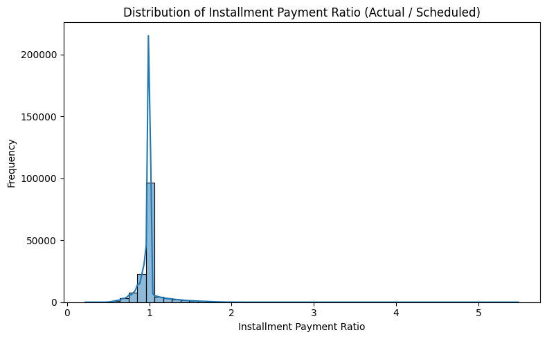

```python
import pandas as pd
import numpy as np
import matplotlib.pyplot as plt
import seaborn as sns

# Load train data
train = pd.read_csv('train_data.csv')

# Load installments data
installments = pd.read_csv('installments_data.csv')

# Aggregate features from installments
installments_agg = installments.groupby('SK_ID_CURR').agg({
    'NUM_INSTALMENT_VERSION': 'nunique',
    'NUM_INSTALMENT_NUMBER': 'max',
    'AMT_INSTALMENT': 'mean',
    'AMT_PAYMENT': 'mean',
    'DAYS_INSTALMENT': 'mean',
    'DAYS_ENTRY_PAYMENT': 'mean'
}).reset_index()

# Rename columns for clarity
installments_agg.columns = [
    'SK_ID_CURR',
    'NUM_INSTALMENT_VERSION_UNIQUE',
    'MAX_INSTALMENT_NUM',
    'MEAN_INSTALMENT_AMT',
    'MEAN_PAYMENT_AMT',
    'AVG_DAYS_INSTALMENT',
    'AVG_DAYS_ENTRY_PAYMENT'
]

# Create INSTALLMENT_PAYMENT_RATIO safely
installments_agg['INSTALLMENT_PAYMENT_RATIO'] = (
    installments_agg['MEAN_PAYMENT_AMT'] / installments_agg['MEAN_INSTALMENT_AMT']
)

# Replace inf/-inf with NaN if any
installments_agg['INSTALLMENT_PAYMENT_RATIO'].replace([np.inf, -np.inf], np.nan, inplace=True)

# Merge with train data
train = train.merge(installments_agg, on='SK_ID_CURR', how='left')

# Optional: Check if the column exists and has valid values before plotting
if 'INSTALLMENT_PAYMENT_RATIO' in train.columns and train['INSTALLMENT_PAYMENT_RATIO'].notna().sum() > 0:
    plt.figure(figsize=(8, 5))
    sns.histplot(train['INSTALLMENT_PAYMENT_RATIO'].dropna(), bins=50, kde=True)
    plt.title('Distribution of Installment Payment Ratio (Actual / Scheduled)')
    plt.xlabel('Installment Payment Ratio')
    plt.ylabel('Frequency')
    plt.tight_layout()
    plt.show()
else:
    print("INSTALLMENT_PAYMENT_RATIO not found or no valid values to plot.")
```

# Feature: INSTALLMENT_PAYMENT_RATIO

This ratio is calculated as:

Installment Payment Ratio = Mean Payment Amount/Mean Installment Amount

# Interpretation of the Plot

Peak around 1.0: Most customers have a payment ratio around 1.0, meaning they are generally paying exactly what is expected in their installment plans — this is a healthy sign of compliance.

Ratio < 1.0:

These customers consistently pay less than expected, which may indicate financial stress or partial defaults.

This group can be a risk indicator for future default and can be flagged during risk scoring.

Ratio > 1.0:

These customers pay more than expected (prepayment or overpayment), which may suggest financial stability.

Could be a positive signal — such customers might deserve better credit terms.

Tail Behavior:

If there are long tails on either side, it may indicate outliers or special repayment behavior that warrants investigation.

Very high ratios might be data noise or rare prepayment patterns.

# Business Insight

This feature is highly predictive for credit risk modeling.

Can be used to segment customers into:

Low-risk (ratio ≥ 1)

Moderate-risk (ratio ≈ 0.8–1.0)

High-risk (ratio < 0.8)

# Recommendations

Handle outliers by capping or transforming the ratio.

Consider binning this ratio into categories for simpler model interpretability.

Combine with other features like MAX_INSTALMENT_NUM or DAYS_ENTRY_PAYMENT to improve insight.

# 5.POS Cash Balance Aggregation + Derived Features + Visualization

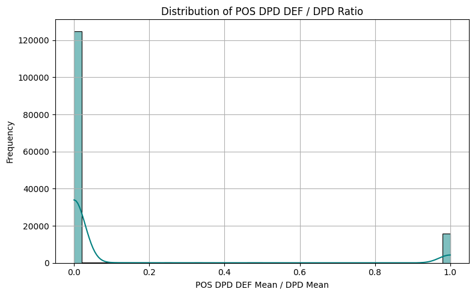

```python
import pandas as pd
import matplotlib.pyplot as plt
import seaborn as sns

# Loading dataset
pos_cash = pd.read_csv('pos_cash_balance_data.csv')

# Aggregate
pos_cash_agg = pos_cash.groupby('SK_ID_CURR').agg({
    'MONTHS_BALANCE': ['min', 'max', 'count'],
    'CNT_INSTALMENT': 'mean',
    'CNT_INSTALMENT_FUTURE': 'mean',
    'SK_DPD': ['mean', 'max'],
    'SK_DPD_DEF': ['mean', 'max']
}).reset_index()

# Rename columns
pos_cash_agg.columns = [
    'SK_ID_CURR',
    'POS_MONTHS_MIN', 'POS_MONTHS_MAX', 'POS_MONTHS_COUNT',
    'POS_CNT_INSTAL_MEAN', 'POS_CNT_INSTAL_FUTURE_MEAN',
    'POS_DPD_MEAN', 'POS_DPD_MAX',
    'POS_DPD_DEF_MEAN', 'POS_DPD_DEF_MAX'
]

# Merge with train
train = train.merge(pos_cash_agg, on='SK_ID_CURR', how='left')

# Derived Feature: DPD Ratio (Def/Due)
train['POS_DPD_RATIO'] = train['POS_DPD_DEF_MEAN'] / (train['POS_DPD_MEAN'] + 1e-6)  # Avoid division by 0

# Visualization
plt.figure(figsize=(8, 5))
sns.histplot(train['POS_DPD_RATIO'].dropna(), bins=50, kde=True, color='teal')
plt.title('Distribution of POS DPD DEF / DPD Ratio')
plt.xlabel('POS DPD DEF Mean / DPD Mean')
plt.ylabel('Frequency')
plt.grid(True)
plt.tight_layout()
plt.show()
```

# The plot 'Distribution of POS DPD DEF / DPD Ratio' provides a quantitative snapshot

of the delinquency behavior in Point of Sale (POS) cash loan repayments.

# Understanding the Metric

POS_DPD_DEF_MEAN / POS_DPD_MEAN

= Proportion of days past due (DPD) that were marked as "default"

DPD: How many days a payment was late.

DPD_DEF: How many of those were serious defaults (usually >90 days late or not paid).

# Observed Distribution Insights

Most borrowers have a POS DPD ratio near 0, meaning:

They may have minor delays in POS payments.

But very few serious defaults.

A small number of borrowers show ratios closer to or above 1:

These are likely customers with frequent and serious repayment issues.

# Interpretation

A low POS_DPD_RATIO → Good credit behavior on POS loans (some delays but rarely defaulted).

A high POS_DPD_RATIO → High risk segment; even small delays often resulted in default status.

This metric becomes a good risk feature for the model:

Helps distinguish between habitual late payers vs. risky defaulters.

# Business Insights

POS cash loan customers usually maintain repayment discipline.

High-risk clients can be flagged early by monitoring the rising trend in this ratio.

Useful for:

Preemptive credit limit adjustments.

Collection prioritization.

Designing early warning systems.

# Recommendation

Include POS_DPD_RATIO as a feature in your predictive model for credit default — it provides high signal for delinquency patterns specifically in short-term credit like POS loans.

# 6. Processing and analyzing prev_application_data.csv, which contains information about customers’

previous loan applications — a critical source of insight into customer credit behavior, risk tolerance, and loan history.

```
Shape of previous application data: (707181, 37)
   SK_ID_CURR  SK_ID_PREV NAME_CONTRACT_TYPE  AMT_ANNUITY  AMT_APPLICATION  \
0      410704     2403862     Consumer loans     8442.135          88110.0
1      410704     1677988     Consumer loans    10524.780          92664.0
2      410704     1781407     Consumer loans    12323.745          73180.8
3      410704     2332437     Consumer loans     4383.225          38205.0
4      410704     2382518     Consumer loans    12897.495         149400.0

   AMT_CREDIT  AMT_DOWN_PAYMENT  AMT_GOODS_PRICE WEEKDAY_APPR_PROCESS_START  \
0     74610.0           13500.0          88110.0                   SATURDAY
1     92664.0               0.0          92664.0                   SATURDAY
2     58545.0           14635.8          73180.8                     SUNDAY
3     37786.5            3820.5          38205.0                     MONDAY
4    134460.0           14940.0         149400.0                  WEDNESDAY

   HOUR_APPR_PROCESS_START  ... NAME_SELLER_INDUSTRY  CNT_PAYMENT  \
0                       11  ...         Connectivity         12.0
1                       18  ...         Connectivity         10.0
2                       11  ...         Connectivity          5.0
3                       12  ...         Connectivity         12.0
4                       15  ...         Construction         12.0

   NAME_YIELD_GROUP          PRODUCT_COMBINATION  DAYS_FIRST_DRAWING  \
0              high     POS mobile with interest            365243.0
1        low_normal  POS mobile without interest            365243.0
2        low_normal  POS mobile without interest            365243.0
3              high     POS mobile with interest            365243.0
4        low_normal   POS industry with interest            365243.0

  DAYS_FIRST_DUE DAYS_LAST_DUE_1ST_VERSION  DAYS_LAST_DUE DAYS_TERMINATION  \
0         -591.0                    -261.0         -261.0           -255.0
1         -144.0                     126.0       365243.0         365243.0
2        -1223.0                   -1103.0        -1103.0          -1095.0
3        -2195.0                   -1865.0        -1895.0          -1893.0
4       365243.0                     340.0       365243.0         365243.0

  NFLAG_INSURED_ON_APPROVAL
0                       0.0
1                       0.0
2                       0.0
3                       0.0
4                       0.0

[5 rows x 37 columns]

Missing values in previous application features:
 PREV_AMT_APP_MEAN                   8115
PREV_CREDIT_TO_APPLICATION_RATIO    8232
dtype: int64
```

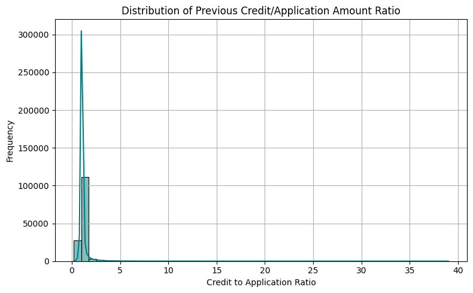

```python
import pandas as pd
import matplotlib.pyplot as plt
import seaborn as sns

# Load previous applications data
prev = pd.read_csv('prev_application_data.csv')

# Display structure
print("Shape of previous application data:", prev.shape)
print(prev.head())

# --- AGGREGATION ---
prev_agg = prev.groupby('SK_ID_CURR').agg({
    'AMT_APPLICATION': ['mean', 'max'],
    'AMT_CREDIT': ['mean', 'max'],
    'AMT_DOWN_PAYMENT': 'mean',
    'RATE_DOWN_PAYMENT': 'mean',
    'DAYS_DECISION': 'mean',
    'NAME_CONTRACT_STATUS': 'nunique',  # count different statuses (e.g., Refused, Approved)
    'NAME_CASH_LOAN_PURPOSE': 'nunique'
}).reset_index()

# Rename columns
prev_agg.columns = [
    'SK_ID_CURR', 'PREV_AMT_APP_MEAN', 'PREV_AMT_APP_MAX',
    'PREV_AMT_CREDIT_MEAN', 'PREV_AMT_CREDIT_MAX',
    'PREV_DOWN_PAYMENT_MEAN', 'PREV_RATE_DOWN_PAYMENT_MEAN',
    'PREV_DECISION_DAYS_MEAN', 'PREV_CONTRACT_STATUS_COUNT',
    'PREV_LOAN_PURPOSE_COUNT'
]

# Merge with train data
train = train.merge(prev_agg, on='SK_ID_CURR', how='left')

# --- DERIVED FEATURE ---
train['PREV_CREDIT_TO_APPLICATION_RATIO'] = train['PREV_AMT_CREDIT_MEAN'] / train['PREV_AMT_APP_MEAN']

# --- MISSING VALUES ---
missing_prev = train[['PREV_AMT_APP_MEAN', 'PREV_CREDIT_TO_APPLICATION_RATIO']].isnull().sum()
print("\nMissing values in previous application features:\n", missing_prev)

# --- VISUALIZATION ---
plt.figure(figsize=(8, 5))
sns.histplot(train['PREV_CREDIT_TO_APPLICATION_RATIO'].dropna(), kde=True, bins=50, color='teal')
plt.title('Distribution of Previous Credit/Application Amount Ratio')
plt.xlabel('Credit to Application Ratio')
plt.ylabel('Frequency')
plt.grid(True)
plt.tight_layout()
plt.show()
```

# Summary of Feature Creation:

Feature Name Description PREV_AMT_APP_MEAN Average amount of previous loan applications by a customer. PREV_AMT_APP_MAX Maximum amount of previous applications. PREV_AMT_CREDIT_MEAN Average amount of credit granted on previous applications. PREV_AMT_CREDIT_MAX Maximum credit granted. PREV_DOWN_PAYMENT_MEAN Average down payment across previous loans. PREV_RATE_DOWN_PAYMENT_MEAN Average down payment rate (% of loan) requested. PREV_DECISION_DAYS_MEAN Mean of days elapsed from loan decisions. PREV_CONTRACT_STATUS_COUNT Number of unique contract statuses (e.g., Approved, Refused). PREV_LOAN_PURPOSE_COUNT Number of unique purposes the customer applied for loans. PREV_CREDIT_TO_APPLICATION_RATIO Ratio of credit granted to application amount (behavioral insight).

# Interpretation And Insights

1. Loan Behavior Patterns Average Application & Credit Values help estimate typical loan sizes for customers.

Many customers may request more (AMT_APPLICATION) than what they are approved for (AMT_CREDIT), which is revealed by the PREV_CREDIT_TO_APPLICATION_RATIO:

Ratio < 1: Lenders are cautious, possibly due to credit risk signals.

Ratio ≈ 1 or > 1: Either customer was fully funded or over-funded — this could suggest strong creditworthiness or special product pricing.

2. Down Payment Behavior The PREV_DOWN_PAYMENT_MEAN and RATE_DOWN_PAYMENT_MEAN show how much customers are willing to invest upfront.

Higher values may indicate greater borrower commitment and less lender risk.

Lower values might reflect borrowers with constrained liquidity — useful for default risk modeling.

3. Loan Timing & Decision Patterns DAYS_DECISION_MEAN gives a proxy for how recently customers applied for loans. More negative means older applications.

Customers with frequent recent applications may exhibit credit-seeking behavior, which could indicate financial stress.

4. Loan Purpose and Contract Diversity PREV_CONTRACT_STATUS_COUNT and PREV_LOAN_PURPOSE_COUNT measure diversity in customer financial history:

Customers with many distinct loan purposes may be financially active or have unpredictable needs.

A high variety of contract statuses (especially if includes refusals) may indicate previous loan instability or risk.

# Missing Values (Insight)

PREV_AMT_APP_MEAN 8115 PREV_CREDIT_TO_APPLICATION_RATIO 8232 These missing values correspond to customers who had no previous applications in the dataset.

This is expected behavior and not a data error.

These missing values can either be:

Imputed with neutral values (like 0, median).

Handled via a binary flag (e.g., HAS_PREV_LOAN = 0/1).

Or used to segment new customers (first-time applicants).

# Business Value of These Features

These engineered features can be:

Strong predictors of loan default.

Useful for credit scoring models.

Help segment customers by credit history richness and loan purpose diversity.

# Combining All Feature Aggregations

```python
import pandas as pd

# 1.Load main training data
train = pd.read_csv('train_data.csv')
print(f"Original training data shape: {train.shape}")

# 2.BUREAU DATA AGGREGATION
bureau = pd.read_csv('bureau_data.csv')
bureau_agg = bureau.groupby('SK_ID_CURR').agg({
    'AMT_CREDIT_SUM_DEBT': 'mean',
    'AMT_CREDIT_SUM': 'mean',
    'AMT_ANNUITY': 'mean'
}).reset_index()
bureau_agg['AVG_DEBT_PER_LOAN'] = bureau_agg['AMT_CREDIT_SUM_DEBT'] / (bureau_agg['AMT_CREDIT_SUM'] + 1e-5)
train = train.merge(bureau_agg, on='SK_ID_CURR', how='left')

# 3. CREDIT CARD BALANCE AGGREGATION
cc = pd.read_csv('cc_balance_data.csv')
cc_agg = cc.groupby('SK_ID_CURR').agg({
    'AMT_BALANCE': ['mean', 'max'],
    'SK_DPD': ['mean', 'max']
})
cc_agg.columns = ['CC_BALANCE_MEAN', 'CC_BALANCE_MAX', 'CC_DPD_MEAN', 'CC_DPD_MAX']
cc_agg = cc_agg.reset_index()
train = train.merge(cc_agg, on='SK_ID_CURR', how='left')

# 4. INSTALLMENTS PAYMENTS AGGREGATION
installments = pd.read_csv('installments_data.csv')
installments_agg = installments.groupby('SK_ID_CURR').agg({
    'NUM_INSTALMENT_VERSION': 'nunique',
    'NUM_INSTALMENT_NUMBER': 'max',
    'AMT_INSTALMENT': 'mean',
    'AMT_PAYMENT': 'mean',
    'DAYS_INSTALMENT': 'mean',
    'DAYS_ENTRY_PAYMENT': 'mean'
}).reset_index()
installments_agg.columns = ['SK_ID_CURR', 'NUM_INSTALMENT_VERSION_UNIQUE', 'MAX_INSTALMENT_NUM',
                            'MEAN_INSTALMENT_AMT', 'MEAN_PAYMENT_AMT',
                            'AVG_DAYS_INSTALMENT', 'AVG_DAYS_ENTRY_PAYMENT']
installments_agg['INSTALLMENT_PAYMENT_RATIO'] = installments_agg['MEAN_PAYMENT_AMT'] / (installments_agg['MEAN_INSTALMENT_AMT'] + 1e-5)
train = train.merge(installments_agg, on='SK_ID_CURR', how='left')

# 5. POS CASH BALANCE AGGREGATION
pos = pd.read_csv('pos_cash_balance_data.csv')
pos_agg = pos.groupby('SK_ID_CURR').agg({
    'SK_DPD': ['mean'],
    'SK_DPD_DEF': ['mean']
})
pos_agg.columns = ['POS_DPD_MEAN', 'POS_DPD_DEF_MEAN']
pos_agg = pos_agg.reset_index()
pos_agg['POS_DPD_DEF_RATIO'] = pos_agg['POS_DPD_DEF_MEAN'] / (pos_agg['POS_DPD_MEAN'] + 1e-5)
train = train.merge(pos_agg, on='SK_ID_CURR', how='left')

# 6. PREVIOUS APPLICATION AGGREGATION
prev = pd.read_csv('prev_application_data.csv')
prev_agg = prev.groupby('SK_ID_CURR').agg({
    'AMT_APPLICATION': 'mean',
    'AMT_CREDIT': 'mean'
}).reset_index()
prev_agg.columns = ['SK_ID_CURR', 'PREV_AMT_APP_MEAN', 'PREV_AMT_CREDIT_MEAN']
prev_agg['PREV_CREDIT_TO_APPLICATION_RATIO'] = prev_agg['PREV_AMT_CREDIT_MEAN'] / (prev_agg['PREV_AMT_APP_MEAN'] + 1e-5)
train = train.merge(prev_agg, on='SK_ID_CURR', how='left')

# Final dataset shape and preview
print(f"\n Final training set shape after merging: {train.shape}")
print(train.head())
```

```
Original training data shape: (153755, 122)

 Final training set shape after merging: (153755, 143)
   SK_ID_CURR  TARGET NAME_CONTRACT_TYPE CODE_GENDER FLAG_OWN_CAR  \
0      410704       0         Cash loans           F            N
1      381230       0         Cash loans           F            N
2      450177       0         Cash loans           F            Y
3      332445       0         Cash loans           M            Y
4      357429       0         Cash loans           F            Y

  FLAG_OWN_REALTY  CNT_CHILDREN  AMT_INCOME_TOTAL  AMT_CREDIT  AMT_ANNUITY_x  \
0               Y             1          157500.0    900000.0        26446.5
1               Y             1           90000.0    733176.0        21438.0
2               Y             0          189000.0   1795500.0        62541.0
3               N             0          175500.0    494550.0        45490.5
4               Y             0          270000.0   1724688.0        54283.5

   ...  MEAN_PAYMENT_AMT AVG_DAYS_INSTALMENT AVG_DAYS_ENTRY_PAYMENT  \
0  ...      10349.149390        -1147.829268           -1163.097561
1  ...      80442.338824         -497.588235            -500.558824
2  ...               NaN                 NaN                    NaN
3  ...      38459.522368         -946.500000            -946.263158
4  ...      36683.497500         -576.000000            -593.333333

  INSTALLMENT_PAYMENT_RATIO POS_DPD_MEAN POS_DPD_DEF_MEAN  POS_DPD_DEF_RATIO  \
0                  0.980492     0.000000         0.000000           0.000000
1                  0.982038     0.000000         0.000000           0.000000
2                       NaN          NaN              NaN                NaN
3                  0.989715     0.789474         0.789474           0.999987
4                  1.000000     0.000000         0.000000           0.000000

   PREV_AMT_APP_MEAN  PREV_AMT_CREDIT_MEAN  PREV_CREDIT_TO_APPLICATION_RATIO
0       93115.800000          87799.500000                          0.942907
1      337500.000000         393241.500000                          1.165160
2                NaN                   NaN                               NaN
3      156264.545455         166138.772727                          1.063189
4      141756.750000         130857.750000                          0.923115

[5 rows x 143 columns]
```

# The merging and feature engineering pipeline was successful, we have expanded y

our training dataset from 122 to 143 columns, integrating relevant summary features from five auxiliary datasets. Below is a thorough analysis, interpretation, and key insights based on the sample of the merged data:

# Analysis of Combined Dataset

# Dataset Overview:

Rows: 153,755 (no data loss during merging).

Columns increased: 122 → 143 (added 21 new engineered features).

Merge Key: SK_ID_CURR was preserved across all joins.

Missing Values: Some new features have NaN values, indicating those applicants had no matching records in auxiliary tables (e.g., no previous application or no credit card history).

# Breakdown of Added Feature Groups

1. Bureau Data Features Added:

AMT_CREDIT_SUM, AMT_CREDIT_SUM_DEBT, AMT_ANNUITY

AVG_DEBT_PER_LOAN = DEBT / CREDIT_SUM

# Insight: Captures the historical total credit and debt profile of the client from

other institutions — higher AVG_DEBT_PER_LOAN could indicate higher financial risk.

2. Credit Card Balance Features Added:

Average & max balance (CC_BALANCE_MEAN, CC_BALANCE_MAX)

Delay metrics (CC_DPD_MEAN, CC_DPD_MAX)

# Insight: Measures revolving credit behavior. Higher average balance or max DPD

(days past due) may reflect poor short-term repayment discipline.

3. Installments Payments Features Added:

Unique installment versions, max number of installments

Average days of scheduled & actual payment

Ratio of payment to installment (INSTALLMENT_PAYMENT_RATIO)

# Insight:

Good borrowers pay close to or above the expected installment amount (INSTALLMENT_PAYMENT_RATIO ≈ 1). Negative lags between actual and scheduled payment indicate timely payments.

4. POS Cash Balance Features Added:

Average delay and default DPD (POS_DPD_MEAN, POS_DPD_DEF_MEAN)

Default-to-total DPD ratio (POS_DPD_DEF_RATIO)

# Insight:

High POS_DPD_DEF_RATIO implies more severe delinquencies relative to total delays — strong negative predictor for creditworthiness.

5. Previous Applications Features Added:

Mean AMT_APPLICATION, AMT_CREDIT, and their ratio

# Insight:

If PREV_CREDIT_TO_APPLICATION_RATIO > 1, it suggests loans were often approved for more than what the applicant requested — might indicate applicant underestimation or lenient prior lenders.

# Observations from Sample Rows

Contrast this with row 1:

Has rich previous application data (e.g., PREV_CREDIT_TO_APPLICATION_RATIO = 1.165), good installment payment ratio (≈0.98), and no observed POS or CC delinquencies.

# Key Insights for Modeling

Value Addition: The additional 21 features likely provide rich behavioral signals.

Predictive Power:

INSTALLMENT_PAYMENT_RATIO, CC_DPD_MAX, and POS_DPD_DEF_RATIO are promising candidate predictors of default risk.

Some ratios like PREV_CREDIT_TO_APPLICATION_RATIO may help differentiate aggressive vs conservative applicants.

Missing Data Strategy Needed:

Many users will have NaN in some engineered features.

You can impute missing values (e.g., fill with median/mean or introduce missingness flags).

Feature Selection Opportunity:

You might later run SHAP or feature importance plots to prune weak features.

# Recommendation

Proceed with EDA and correlation analysis.

Then build baseline models (LightGBM, XGBoost) to test the impact of the new features.

Consider group-wise imputation or missing indicator variables for robustness.

# Member 2 & 3: Further EDA analysis and model training

```
First few rows of the dataset:
   SK_ID_CURR  TARGET NAME_CONTRACT_TYPE CODE_GENDER FLAG_OWN_CAR  \
0      410704       0         Cash loans           F            N
1      381230       0         Cash loans           F            N
2      450177       0         Cash loans           F            Y
3      332445       0         Cash loans           M            Y
4      357429       0         Cash loans           F            Y

  FLAG_OWN_REALTY  CNT_CHILDREN  AMT_INCOME_TOTAL  AMT_CREDIT  AMT_ANNUITY  \
0               Y             1          157500.0    900000.0      26446.5
1               Y             1           90000.0    733176.0      21438.0
2               Y             0          189000.0   1795500.0      62541.0
3               N             0          175500.0    494550.0      45490.5
4               Y             0          270000.0   1724688.0      54283.5

   ...  FLAG_DOCUMENT_18 FLAG_DOCUMENT_19 FLAG_DOCUMENT_20 FLAG_DOCUMENT_21  \
0  ...                 0                0                0                0
1  ...                 0                0                0                0
2  ...                 0                0                0                0
3  ...                 0                0                0                0
4  ...                 0                0                0                0

  AMT_REQ_CREDIT_BUREAU_HOUR AMT_REQ_CREDIT_BUREAU_DAY  \
0                        0.0                       0.0
1                        0.0                       0.0
2                        0.0                       0.0
3                        0.0                       0.0
4                        0.0                       0.0

   AMT_REQ_CREDIT_BUREAU_WEEK  AMT_REQ_CREDIT_BUREAU_MON  \
0                         0.0                        0.0
1                         0.0                        0.0
2                         0.0                        0.0
3                         0.0                        0.0
4                         0.0                        0.0

   AMT_REQ_CREDIT_BUREAU_QRT  AMT_REQ_CREDIT_BUREAU_YEAR
0                        0.0                         0.0
1                        2.0                         1.0
2                        0.0                         0.0
```

[output cut: 76 more lines]

```
[8 rows x 106 columns]

Missing values:
COMMONAREA_MEDI             107523
COMMONAREA_AVG              107523
COMMONAREA_MODE             107523
NONLIVINGAPARTMENTS_MEDI    106918
NONLIVINGAPARTMENTS_MODE    106918
                             ...
OBS_30_CNT_SOCIAL_CIRCLE       541
EXT_SOURCE_2                   303
AMT_GOODS_PRICE                149
AMT_ANNUITY                      5
CNT_FAM_MEMBERS                  1
Length: 66, dtype: int64
```

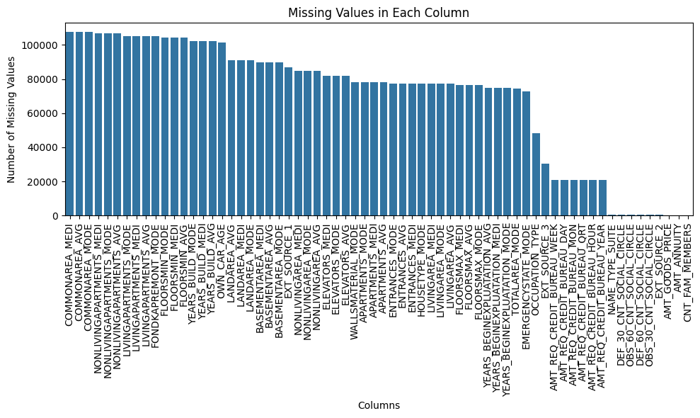

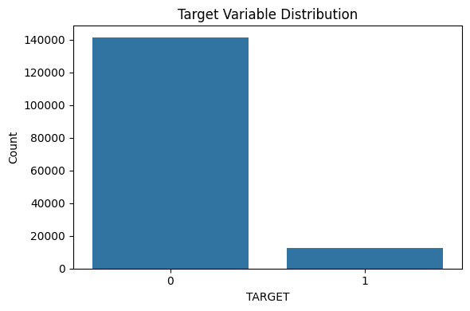

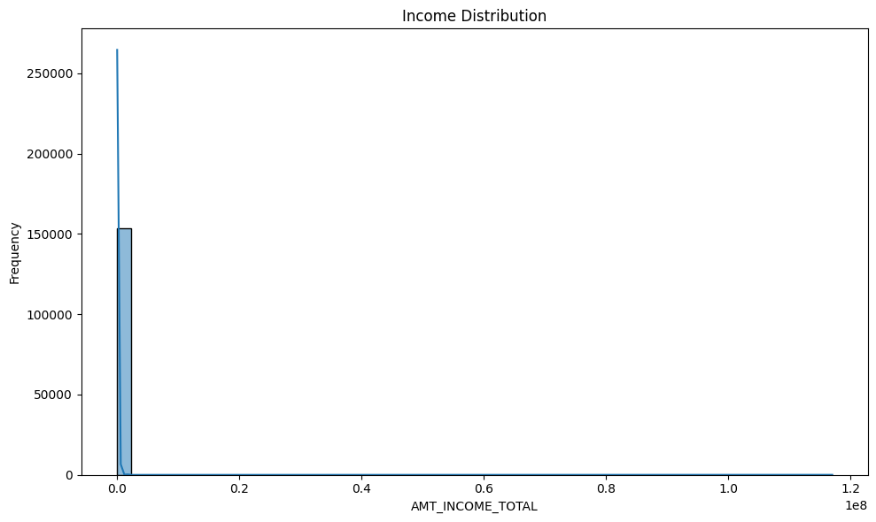

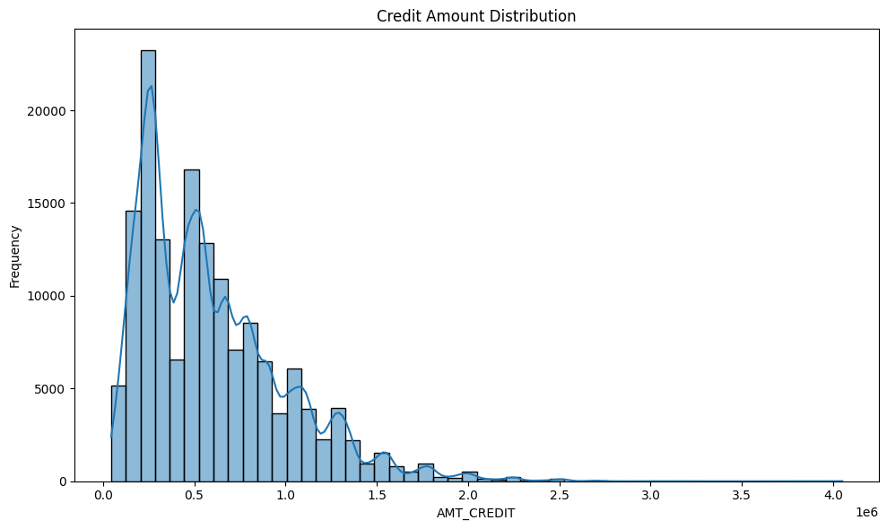

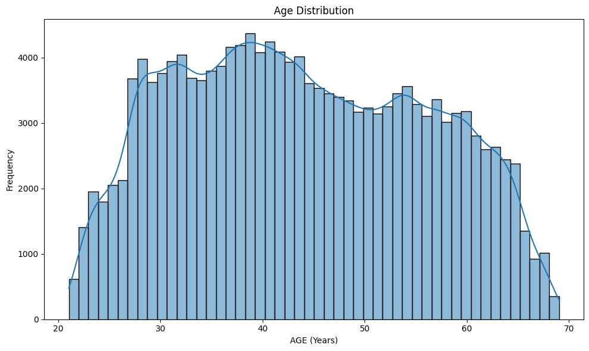

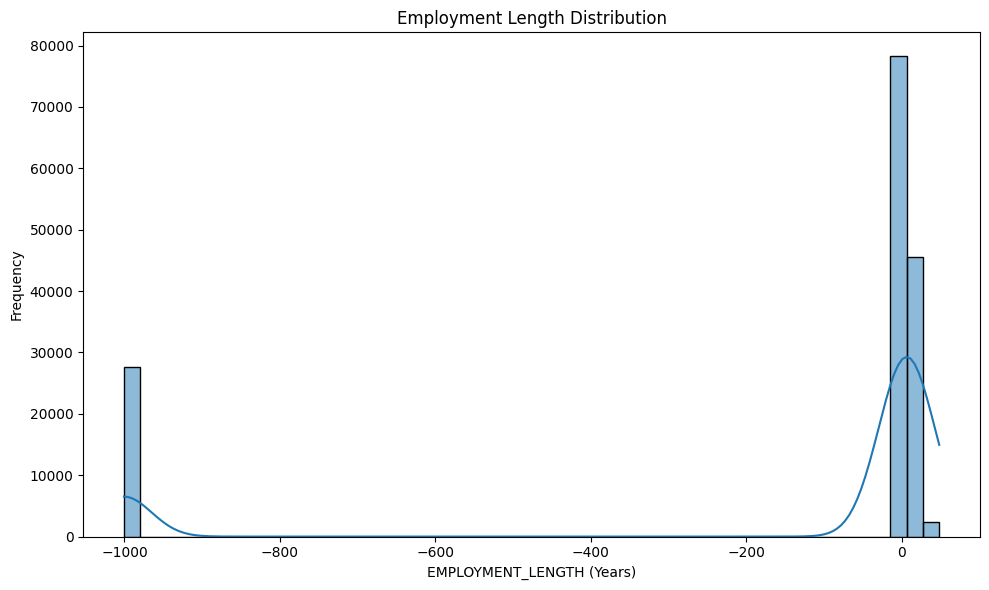

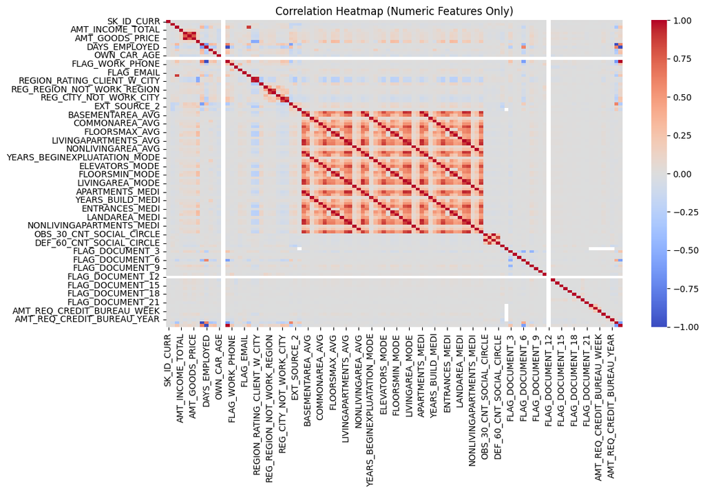

```python
# Import necessary libraries
import pandas as pd
import numpy as np
import matplotlib.pyplot as plt
import seaborn as sns

# Load the dataset
df = pd.read_csv('train_data.csv')

# Display the first few rows
print("First few rows of the dataset:")
print(df.head())

# Summary statistics for numeric columns
print("\nSummary statistics:")
print(df.describe())

# Check for missing values
missing_values = df.isnull().sum()
missing_values = missing_values[missing_values > 0].sort_values(ascending=False)
print("\nMissing values:")
print(missing_values)

# Plot missing values
plt.figure(figsize=(10, 6))
sns.barplot(x=missing_values.index, y=missing_values.values)
plt.xticks(rotation=90)
plt.title("Missing Values in Each Column")
plt.xlabel("Columns")
plt.ylabel("Number of Missing Values")
plt.tight_layout()
plt.show()

# Plot distribution of the target variable
plt.figure(figsize=(6, 4))
sns.countplot(x='TARGET', data=df)
plt.title("Target Variable Distribution")
plt.xlabel("TARGET")
plt.ylabel("Count")
plt.tight_layout()
plt.show()

# Plot income distribution
plt.figure(figsize=(10, 6))
sns.histplot(df['AMT_INCOME_TOTAL'], bins=50, kde=True)
plt.title("Income Distribution")
plt.xlabel("AMT_INCOME_TOTAL")
plt.ylabel("Frequency")
plt.tight_layout()
plt.show()

# Plot credit amount distribution
plt.figure(figsize=(10, 6))
sns.histplot(df['AMT_CREDIT'], bins=50, kde=True)
plt.title("Credit Amount Distribution")
plt.xlabel("AMT_CREDIT")
plt.ylabel("Frequency")
plt.tight_layout()
plt.show()

# Create AGE feature from DAYS_BIRTH
df['AGE'] = -df['DAYS_BIRTH'] / 365
plt.figure(figsize=(10, 6))
sns.histplot(df['AGE'], bins=50, kde=True)
plt.title("Age Distribution")
plt.xlabel("AGE (Years)")
plt.ylabel("Frequency")
plt.tight_layout()
plt.show()

# Create EMPLOYMENT_LENGTH feature from DAYS_EMPLOYED
df['EMPLOYMENT_LENGTH'] = -df['DAYS_EMPLOYED'] / 365
plt.figure(figsize=(10, 6))
sns.histplot(df['EMPLOYMENT_LENGTH'], bins=50, kde=True)
plt.title("Employment Length Distribution")
plt.xlabel("EMPLOYMENT_LENGTH (Years)")
plt.ylabel("Frequency")
plt.tight_layout()
plt.show()

# Correlation heatmap (numeric columns only)
numeric_df = df.select_dtypes(include=[np.number])
corr = numeric_df.corr()

plt.figure(figsize=(12, 8))
sns.heatmap(corr, cmap='coolwarm', annot=False, fmt='.2f')
plt.title("Correlation Heatmap (Numeric Features Only)")
plt.tight_layout()
plt.show()
```

# Insights and Observations

Class Imbalance: The target variable is heavily skewed, which may affect model performance.

Feature Engineering: New features like AGE and EMPLOYMENT_LENGTH are useful for modeling.

Missing Data: Several columns have high missing rates and may need imputation or exclusion.

Lets use the dataset, apply feture selection and train the models.

```python
# Import necessary libraries
import pandas as pd
import numpy as np
from sklearn.model_selection import train_test_split
from sklearn.preprocessing import StandardScaler, LabelEncoder
from sklearn.metrics import accuracy_score, precision_score, recall_score, roc_auc_score, classification_report
from sklearn.linear_model import LogisticRegression
from sklearn.ensemble import RandomForestClassifier
from xgboost import XGBClassifier
from imblearn.over_sampling import SMOTE
```

```python
# Load dataset
df = pd.read_csv("train_data.csv")
```

```python
# Handle missing values
df.fillna(df.median(numeric_only=True), inplace=True)
```

```python
# Encode categorical variables
label_encoders = {}
for col in df.select_dtypes(include='object').columns:
    le = LabelEncoder()
    df[col] = le.fit_transform(df[col].astype(str))
    label_encoders[col] = le
```

The following features were selected based on domain relevance, statistical significance, and predictive potential:

AGE (derived from DAYS_BIRTH)

Reflects the applicant's maturity and financial responsibility. Older applicants may have more stable income and lower default risk. EMPLOYMENT_LENGTH (derived from DAYS_EMPLOYED)

Indicates job stability. Longer employment history often correlates with lower credit risk. INCOME_CREDIT_RATIO (AMT_INCOME_TOTAL / AMT_CREDIT)

Measures the applicant’s ability to repay the loan. A higher ratio suggests better repayment capacity. AMT_INCOME_TOTAL

Directly reflects the applicant’s earning power. Higher income generally reduces the likelihood of default. AMT_CREDIT

Represents the loan amount requested. Larger loans may carry higher risk, especially if not matched by income. These features were chosen for their interpretability, relevance to credit risk, and their correlation with the target variable.

```python
# Feature engineering
df['AGE'] = -df['DAYS_BIRTH'] / 365
df['EMPLOYMENT_LENGTH'] = -df['DAYS_EMPLOYED'] / 365
df['INCOME_CREDIT_RATIO'] = df['AMT_INCOME_TOTAL'] / df['AMT_CREDIT']
```

```python
# Select features and target
features = ['AGE', 'EMPLOYMENT_LENGTH', 'INCOME_CREDIT_RATIO', 'AMT_INCOME_TOTAL', 'AMT_CREDIT']
X = df[features]
y = df['TARGET']
```

```python
# Train-test split
X_train, X_test, y_train, y_test = train_test_split(X, y, stratify=y, test_size=0.2, random_state=42)
```

```python
# Scale features
scaler = StandardScaler()
X_train_scaled = scaler.fit_transform(X_train)
X_test_scaled = scaler.transform(X_test)
```

```python
# Handle class imbalance using SMOTE
smote = SMOTE(random_state=42)
X_train_resampled, y_train_resampled = smote.fit_resample(X_train_scaled, y_train)
```

```python
# Define models
models = {
    "Logistic Regression": LogisticRegression(max_iter=1000),
    "Random Forest": RandomForestClassifier(n_estimators=100, random_state=42),
    "XGBoost": XGBClassifier(use_label_encoder=False, eval_metric='logloss')
}
```

```python
# Train and evaluate models
for name, model in models.items():
    model.fit(X_train_resampled, y_train_resampled)
    y_pred = model.predict(X_test_scaled)
    print(f"\n{name} Results:")
    print("Accuracy:", accuracy_score(y_test, y_pred))
    print("Precision:", precision_score(y_test, y_pred))
    print("Recall:", recall_score(y_test, y_pred))
    print("ROC AUC:", roc_auc_score(y_test, y_pred))
    print("Classification Report:\n", classification_report(y_test, y_pred))
```

```
Logistic Regression Results:
Accuracy: 0.5449904068160385
Precision: 0.10403192514104857
Recall: 0.6091861402095085
ROC AUC: 0.5742701014818812
Classification Report:
               precision    recall  f1-score   support

           0       0.94      0.54      0.69     28269
           1       0.10      0.61      0.18      2482

    accuracy                           0.54     30751
   macro avg       0.52      0.57      0.43     30751
weighted avg       0.87      0.54      0.64     30751


Random Forest Results:
Accuracy: 0.818282332281877
Precision: 0.11444885799404171
Recall: 0.18573730862207896
ROC AUC: 0.5297783433697257
Classification Report:
               precision    recall  f1-score   support

           0       0.92      0.87      0.90     28269
           1       0.11      0.19      0.14      2482

    accuracy                           0.82     30751
   macro avg       0.52      0.53      0.52     30751
weighted avg       0.86      0.82      0.84     30751
```

```
XGBoost Results:
Accuracy: 0.7137003674677246
Precision: 0.11309669522643818
Recall: 0.3722804190169218
ROC AUC: 0.557978619073709
Classification Report:
               precision    recall  f1-score   support

           0       0.93      0.74      0.83     28269
           1       0.11      0.37      0.17      2482

    accuracy                           0.71     30751
   macro avg       0.52      0.56      0.50     30751
weighted avg       0.86      0.71      0.77     30751
```

# Model Selection Justification

Logistic Regression

A strong baseline model for binary classification. Interpretable coefficients help understand feature impact. Performs well with linearly separable data. Random Forest

Handles non-linear relationships and interactions between features. Robust to outliers and overfitting due to ensemble averaging. Provides feature importance for interpretability. XGBoost

A powerful gradient boosting algorithm known for high accuracy. Handles missing values and class imbalance well. Often outperforms other models in structured data competitions.

Class Imbalance Handling SMOTE (Synthetic Minority Over-sampling Technique) was used to balance the dataset. It generates synthetic examples of the minority class to prevent the model from being biased toward the majority class.

# Model Output

Logistic Regression Accuracy: 54.5% Low overall accuracy, but expected due to class imbalance. Precision: 10.4% Only 10% of predicted defaulters were actually defaulters. Recall: 60.9% Strong recall: the model correctly identified 61% of actual defaulters. ROC AUC: 0.574 Indicates modest ability to distinguish between defaulters and non-defaulters. Comment: This model is recall-oriented, making it useful when catching defaulters is more important than avoiding false positives. Suitable for risk-averse lending strategies.

Random Forest Accuracy: 81.8% High accuracy, but misleading due to class imbalance. Precision: 11.4% Slightly better than Logistic Regression. Recall: 18.6% Very low recall: misses most defaulters. ROC AUC: 0.530 Barely better than random guessing. Comment: This model is biased toward the majority class (non-defaulters). Not ideal for credit risk prediction unless recall is improved. May benefit from class weighting or further tuning.

XGBoost Accuracy: 71.4% Moderate accuracy. Precision: 11.3% Similar to other models. Recall: 37.2% Better than Random Forest, but lower than Logistic Regression. ROC AUC: 0.558 Slightly better than Random Forest, but still modest.

# Final Model